# PMO - “Módulo inteligente para la toma de decisiones”

[figure not shown]

## Entendimiento del negocio

Actualmente el departamento de proyectos de la empresa Go-Labs Enterprises Solutions S.A cuenta con un sistema de manejo de proyectos llamado "PMO". Esta herramienta de software consta de varios módulos los cuales brindan cierta información sobre los proyectos actuales, tecnologías que se utilizan, miembros de equipo en cada proyecto y otros parámetros los cuales dan a conocer al departamento una vista rápida del estado de estos.

Por otra parte, el departamento de proyectos a identificado cierta carencia sobre los estimadores de proyectos ya que estos se crean a criterio experto pero estos una vez creados y almacenados no siempre son implementados en los proyectos.

Por lo cual se genera el siguiente problema:

- **Carencia sobre la toma de decisiones al predecir cual estimador realmente se va a usar en un proyecto**

Además dicho problema genera la siguiente pregunta:

- **¿Cómo predecir si un estimador realmente va a ser usado en un proyecto a partir de cierta información previa?**

## Enfoque Analítico

Las técnicas de aprendizaje automático permiten predecir cierta clasificación sobre algún dato en especifico a partir de dicha información historica. Por lo que, por medio de un **modelo predictivo de clasificación** se predice si una caracteristica de dicho estimador va o no ser implementada en algún proyecto.

Debido a la gran cantidad de algoritmos de clasificación que existen actualmente es que se obta por usar una herramienta como Pycaret para realizar dicha comparación entre modelos para obtar por el más óptimo y adecuado para dichos datos y predicción.

## Requerimiento de los datos

Para el desarrollo de un modelo de clasificación siempre la variable objetivo tiene que ser un dato de tipo categóricos.

El objetivo de la variable a predecir es indicar si dicho estimador fue o no utilizado en algún proyecto.

El formato de la variable objetivo debería de ser el siguiente:

- *De tipo binario(es usada o no en un proyecto):* **1 (es usada)**, **0 (no es usada)**

El formato para las variables no dependiente pueden tener formatos tanto categóricos como númericos.

**Fuente de datos**

- El sistema PMO almacena los datos en una base de datos relacional PostgreSQL la cual esta desplegada en AWS. Por lo que, se pueden realizar consultas sobre tablas de datos en especifico para extraer la información en un formato adecuado (.csv, .json, .xls o similares) para su uso.

## Colección de datos

Breviamente se descargaron las tablas sobre los proyectos, estimadores e items de los estimadores desde la base de datos en PostgreSQL, dichos datasets fueron almacenados en la cuenta de Drive para la facilidad de reproducción del mismo.

```python
# Set de librerias
import pandas as pd
import numpy as np
```

```python
# Cargamos el csv de google drive
from google.colab import drive
drive.mount('/content/drive')
ROOT = "/content/drive/My Drive/PMO Project/datasets/" # Patch donde se encuentran los datasets
```

```python
# Carga de los datesets a usar
projects_df = pd.read_csv(ROOT+"projects.csv")
estimations_df = pd.read_csv(ROOT+"estimations.csv")
bucket_estimation_df = pd.read_csv(ROOT+"bucket_estimation.csv")
bucket_estimation_items_df = pd.read_csv(ROOT+"bucket_estimation_items.csv")
buckets_df = pd.read_csv(ROOT+"buckets.csv")
```

## Entendimiento de los datos

```python
# Libreria de gráfica
import matplotlib.pyplot as plt
import plotly.express as px
```

### Entendimiento de los datos - **Dataframe de Proyectos**

Este dataframe contiene información registrada de los proyectos realizados en la empresa Go-Labs (73 registros), tales como:

- *id:* Identificador único, númerica
- *name:* Nombre del proyecto, categorica
- *description:* Descripción del proyecto, categorica
- *is_confidential:* Confidencialidad del proyecto, booleana
- *is_internal:* Proyecto interno, booleana
- *type:* Tipo de proyecto, categorica
- *state:* Estado del proyecto, categorica
- *start_date:* Fecha de inicio, categorica
- *end_date:* Fecha final, categorica
- *client_id:* Identificador del cliente, númerica
- *project_status_id:* Identificador del estatus del proyecto, númerica
- *estimation_id:* Identificador de la estimación, númerica
- *deleted_at:* Fecha de eliminación del proyecto en el sistema PMO, categorica
- *created_at:* Fecha de creado del proyecto en el sistema PMO, categorica
- *updated_at:* Fecha de actualizado del proyecto en el sistema PMO, categorica
- *closed_at:* Fecha de cerrado del proyecto en el sistema PMO, categorica

```python
# Vista previa de datos del dataframe de proyectos
projects_df.head()
```

|  | id | name | description | is_confidential | is_internal | type | state | start_date | end_date | client_id | project_status_id | estimation_id | deleted_at | created_at | updated_at | closed_at |
| --- | --- | --- | --- | --- | --- | --- | --- | --- | --- | --- | --- | --- | --- | --- | --- | --- |
| 0 | 23 | Quicktun | <div>System that uses QuickBooks Online (ERP) ... | False | True | Fixed Bid | Completed | 2018-07-01 00:00:00 | 2018-12-31 00:00:00 | 15 | 1 | NaN | NaN | 2020-04-29 18:17:59 | 2020-04-29 18:17:59 | 2018-12-31 00:00:00 |
| 1 | 4 | QPOS | Working on bug fixing and new features for the... | False | False | Retainer Fee | In Progress | 2020-03-16 00:00:00 | 2020-09-15 00:00:00 | 14 | 1 | NaN | NaN | 2020-03-19 21:18:15 | 2020-03-19 21:18:15 | NaN |
| 2 | 2 | Indeed | Devops projects for a client with 2000+ develo... | True | False | Retainer Fee | In Progress | 2020-03-02 00:00:00 | 2020-12-31 00:00:00 | 2 | 1 | NaN | NaN | 2020-03-16 22:49:34 | 2020-03-19 23:25:41 | NaN |
| 3 | 3 | Avium Steps | Design and implement a workflow with AWS lambd... | True | False | Fixed Bid | Completed | 2020-03-18 00:00:00 | 2020-03-20 00:00:00 | 8 | 1 | 1.0 | NaN | 2020-03-18 03:52:50 | 2020-03-20 19:48:57 | 2020-03-20 00:00:00 |
| 4 | 5 | Referenceable | Referenceable is a software that allows compan... | False | False | Fixed Bid | Completed | 2019-11-18 00:00:00 | 2020-05-09 00:00:00 | 5 | 1 | NaN | NaN | 2020-03-25 16:28:57 | 2020-03-25 16:29:29 | 2020-05-09 00:00:00 |

```python
projects_df.info() # Información previa
```

```
<class 'pandas.core.frame.DataFrame'>
RangeIndex: 73 entries, 0 to 72
Data columns (total 16 columns):
 #   Column             Non-Null Count  Dtype
---  ------             --------------  -----
 0   id                 73 non-null     int64
 1   name               73 non-null     object
 2   description        73 non-null     object
 3   is_confidential    73 non-null     bool
 4   is_internal        73 non-null     bool
 5   type               73 non-null     object
 6   state              73 non-null     object
 7   start_date         73 non-null     object
 8   end_date           73 non-null     object
 9   client_id          73 non-null     int64
 10  project_status_id  73 non-null     int64
 11  estimation_id      16 non-null     float64
 12  deleted_at         0 non-null      float64
 13  created_at         73 non-null     object
 14  updated_at         73 non-null     object
 15  closed_at          59 non-null     object
dtypes: bool(2), float64(2), int64(3), object(9)
memory usage: 8.3+ KB
```

```python
# Tamaño del dataframe de proyectos
projects_df.shape
```

```
(73, 16)
```

```python
# Histograma de tipos de proyecto
fig = px.histogram(projects_df, x="type", title="Histograma de tipos de proyecto")
fig.show()
```

[interactive chart not shown]

```python
# Histograma del estado de los proyectos
fig = px.histogram(projects_df, x="state", title="Histograma del estado de los proyectos")
fig.show()
```

[interactive chart not shown]

```python
# Histograma de la cantidad de proyectos confidenciales
fig = px.histogram(projects_df, x="is_confidential", title="Histograma de la cantidad de proyectos confidenciales")
fig.show()
```

[interactive chart not shown]

```python
fig = px.pie(projects_df, values='client_id', title='Porcentaje de proyectos por id del cliente')
fig.update_traces(textposition='inside', textinfo='percent')
fig.show()
```

[interactive chart not shown]

El cliente con el **id 67 es Sula Batsú**, por lo que es el cliente con *más porcentaje de proyectos* dentro de la empresa

```python
fig = px.line(projects_df, y='created_at', title='Serie de tiempo de los proyectos creados')

fig.update_xaxes(rangeslider_visible=True)
fig.show()
```

[interactive chart not shown]

### Entendimiento de los datos - **Dataframe de Estimadores**

Este dataframe contiene información registrada de los estimadores de los proyectyos realizados en la empresa Go-Labs (60 registros), tales como:

- *id:* Identificador único, númerica
- *description:* Descripción, categorica
- *client_id:* Identificador del cliente, númerica
- *created_at:* Fecha de creado del proyecto en el sistema PMO, categorica
- *updated_at:* Fecha de actualizado del proyecto en el sistema PMO, categorica
- *deleted_at:* Fecha de eliminación del proyecto en el sistema PMO, categorica
- *notes:* Notas, categorica

```python
estimations_df.head()
```

|  | id | description | client_id | created_at | updated_at | deleted_at | notes |
| --- | --- | --- | --- | --- | --- | --- | --- |
| 0 | 1 | Avium Steps | 8 | 2020-03-16 23:31:23 | 2020-03-16 23:31:23 | NaN | NaN |
| 1 | 2 | Local Market | 15 | 2020-03-25 18:01:07 | 2020-03-25 18:01:07 | NaN | NaN |
| 2 | 3 | Liquidation App (Antiblock) | 12 | 2020-03-25 21:01:22 | 2020-03-25 21:01:22 | NaN | NaN |
| 3 | 4 | Referenceable transcoder | 5 | 2020-03-26 21:24:52 | 2020-03-26 21:24:52 | NaN | NaN |
| 4 | 5 | Face Recognition Project | 18 | 2020-03-30 22:03:11 | 2020-03-30 22:03:11 | NaN | NaN |

```python
estimations_df.info() # Información previa
```

```
<class 'pandas.core.frame.DataFrame'>
RangeIndex: 60 entries, 0 to 59
Data columns (total 7 columns):
 #   Column       Non-Null Count  Dtype
---  ------       --------------  -----
 0   id           60 non-null     int64
 1   description  60 non-null     object
 2   client_id    60 non-null     int64
 3   created_at   60 non-null     object
 4   updated_at   60 non-null     object
 5   deleted_at   2 non-null      object
 6   notes        1 non-null      object
dtypes: int64(2), object(5)
memory usage: 3.4+ KB
```

```python
estimations_df.shape
```

```
(60, 7)
```

```python
fig = px.line(estimations_df, y='created_at', title='Serie de tiempo de los estimadores creados')

fig.update_xaxes(rangeslider_visible=True)
fig.show()
```

[interactive chart not shown]

### Entendimiento de los datos - **Dataframe del bucket de estimación**

Este dataframe es una tabla intermedia entre los estimadores y sus items (205 registros), tales como:

- *id:* Identificador único, númerica
- *estimation_id:* Identificador del estimador, númerica
- *bucket_id:* Identificador del bucket, númerica
- *created_at:* Fecha de creado del proyecto en el sistema PMO, categorica
- *updated_at:* Fecha de actualizado del proyecto en el sistema PMO, categorica
- *order:* Orden en el que se muestra en el sistema de PMO, númerica

```python
bucket_estimation_df.head()
```

|  | id | estimation_id | bucket_id | created_at | updated_at | order |
| --- | --- | --- | --- | --- | --- | --- |
| 0 | 1 | 1 | 1 | NaN | NaN | NaN |
| 1 | 6 | 3 | 8 | NaN | NaN | NaN |
| 2 | 7 | 3 | 1 | NaN | NaN | NaN |
| 3 | 8 | 3 | 6 | NaN | NaN | NaN |
| 4 | 9 | 3 | 7 | NaN | NaN | NaN |

```python
bucket_estimation_df.shape
```

```
(205, 6)
```

```python
bucket_estimation_df.info()
```

```
<class 'pandas.core.frame.DataFrame'>
RangeIndex: 205 entries, 0 to 204
Data columns (total 6 columns):
 #   Column         Non-Null Count  Dtype
---  ------         --------------  -----
 0   id             205 non-null    int64
 1   estimation_id  205 non-null    int64
 2   bucket_id      205 non-null    int64
 3   created_at     31 non-null     object
 4   updated_at     141 non-null    object
 5   order          130 non-null    float64
dtypes: float64(1), int64(3), object(2)
memory usage: 9.7+ KB
```

### Entendimiento de los datos - **Dataframe de los items de los estimadores**

Este dataframe contiene información registrada de los items de los estimadores de los proyectyos realizados en la empresa Go-Labs (1422 registros), tales como:

- *id:* Identificador único, númerica
- *description:* Descripción del item, categorica
- *hours:* Horas definidas, númerica
- *bucket_estimation_id:* Identificador del bucket de estimación, númerica
- *created_at:* Fecha de creado del proyecto en el sistema PMO, categorica
- *updated_at:* Fecha de actualizado del proyecto en el sistema PMO, categorica
- *deliverable_id:* Identificador del entregable, númerica
- *order:* Orden en el que se muestra en el sistema de PMO, númerica

```python
bucket_estimation_items_df.head()
```

|  | id | description | hours | bucket_estimation_id | created_at | updated_at | deliverable_id | order |
| --- | --- | --- | --- | --- | --- | --- | --- | --- |
| 0 | 1 | Learning AWS Step Functions | 8 | 1 | 2020-03-16 23:33:47 | 2020-03-16 23:33:47 | NaN | 0 |
| 1 | 2 | Configure workflows | 8 | 1 | 2020-03-16 23:33:47 | 2020-03-16 23:33:47 | NaN | 0 |
| 2 | 3 | Deployment to production | 8 | 1 | 2020-03-16 23:33:47 | 2020-03-16 23:33:47 | NaN | 0 |
| 3 | 4 | PM | 2 | 1 | 2020-03-16 23:33:59 | 2020-03-16 23:33:59 | NaN | 0 |
| 4 | 6 | Pantalla de desbloqueo | 8 | 6 | 2020-03-25 21:02:06 | 2020-03-25 21:02:06 | NaN | 0 |

```python
bucket_estimation_items_df.shape
```

```
(1422, 8)
```

```python
bucket_estimation_items_df.info()
```

```
<class 'pandas.core.frame.DataFrame'>
RangeIndex: 1422 entries, 0 to 1421
Data columns (total 8 columns):
 #   Column                Non-Null Count  Dtype
---  ------                --------------  -----
 0   id                    1422 non-null   int64
 1   description           1422 non-null   object
 2   hours                 1422 non-null   int64
 3   bucket_estimation_id  1422 non-null   int64
 4   created_at            1422 non-null   object
 5   updated_at            1422 non-null   object
 6   deliverable_id        1099 non-null   float64
 7   order                 1422 non-null   int64
dtypes: float64(1), int64(4), object(3)
memory usage: 89.0+ KB
```

```python
bucket_estimation_items_df.describe()
```

|  | id | hours | bucket_estimation_id | deliverable_id | order |
| --- | --- | --- | --- | --- | --- |
| count | 1422.000000 | 1422.000000 | 1422.000000 | 1099.000000 | 1422.000000 |
| mean | 825.722925 | 20.794655 | 124.602672 | 49.641492 | 7.191280 |
| std | 467.668101 | 29.343485 | 60.451134 | 31.758348 | 7.806508 |
| min | 1.000000 | 1.000000 | 1.000000 | 1.000000 | 0.000000 |
| 25% | 437.250000 | 8.000000 | 85.000000 | 20.000000 | 1.000000 |
| 50% | 831.500000 | 16.000000 | 131.500000 | 48.000000 | 5.000000 |
| 75% | 1234.750000 | 24.000000 | 172.000000 | 81.000000 | 11.000000 |
| max | 1624.000000 | 400.000000 | 220.000000 | 99.000000 | 39.000000 |

El promedio de horas es de 21 apróximadamente

```python
fig = px.violin(bucket_estimation_items_df, y="hours", box=True,points='all', title ="Distribución de las horas de los items")
fig.show()
```

[interactive chart not shown]

### Entendimiento de los datos - **Dataframe de los items de los buckets**

Este dataframe contiene información registrada de los buckets de los items de los estimadores de los proyectyos realizados en la empresa Go-Labs (17 registros), tales como:

- *id:* Identificador único, númerica
- *description:* Descripción del bucket, categorica
- *created_at:* Fecha de creado del proyecto en el sistema PMO, categorica
- *updated_at:* Fecha de actualizado del proyecto en el sistema PMO, categorica
- *is_parallel:* Si se trabaja en paralelo, categorica

```python
buckets_df.head()
```

|  | id | description | created_at | updated_at | is_parallel |
| --- | --- | --- | --- | --- | --- |
| 0 | 1 | Devops | 2020-03-16 23:29:31 | 2020-03-16 23:29:31 | False |
| 1 | 2 | API | 2020-03-25 17:35:23 | 2020-03-25 17:35:23 | False |
| 2 | 3 | Progressive web app | 2020-03-25 17:45:06 | 2020-03-25 17:45:06 | False |
| 3 | 6 | Android | 2020-03-25 21:00:15 | 2020-03-25 21:00:15 | False |
| 4 | 7 | iOS | 2020-03-25 21:00:20 | 2020-03-25 21:00:20 | False |

```python
buckets_df.shape
```

```
(17, 5)
```

## Preparación de la información

*Para la preparación de los datos hay tre puntos importantes por realizar:*

- Creación la variable objetivo por medio de los proyectos y los estimadores.
- Realizar la unión de los items y los estimadores para obtener cuál item del estimador fue usado en un proyecto y cúal otro no.
- Procesar el detalle de los items por procesamiento del lenguaje natural creando grupos de palabras y así obtienendo la posibilidad de estar en dicho grupo, esto con el objetivo de usar dichas probabilidades como parámetro de entrada del modelo.

**¿Qué es Pycaret?**

- PyCaret es una biblioteca de aprendizaje automático de código abierto y bajo código en Python que le permite pasar de preparar sus datos a implementar su modelo en cuestión de segundos en el entorno de su computadora portátil.

### Creación de la variable objetivo

```python
# Creación de la variable objetivo
## Si el id del estimador esta en el proyecto es 1 sino 0
estimations_df["is_used"] = estimations_df.id.isin(projects_df.estimation_id).astype(int)
```

```python
estimations_df.head()
```

|  | id | description | client_id | created_at | updated_at | deleted_at | notes | is_used |
| --- | --- | --- | --- | --- | --- | --- | --- | --- |
| 0 | 1 | Avium Steps | 8 | 2020-03-16 23:31:23 | 2020-03-16 23:31:23 | NaN | NaN | 1 |
| 1 | 2 | Local Market | 15 | 2020-03-25 18:01:07 | 2020-03-25 18:01:07 | NaN | NaN | 1 |
| 2 | 3 | Liquidation App (Antiblock) | 12 | 2020-03-25 21:01:22 | 2020-03-25 21:01:22 | NaN | NaN | 1 |
| 3 | 4 | Referenceable transcoder | 5 | 2020-03-26 21:24:52 | 2020-03-26 21:24:52 | NaN | NaN | 1 |
| 4 | 5 | Face Recognition Project | 18 | 2020-03-30 22:03:11 | 2020-03-30 22:03:11 | NaN | NaN | 1 |

```python
# Histograma de la cantidad de items usados y no usados en proyectos
fig = px.histogram(estimations_df, x="is_used", title="Histograma de la cantidad de items usados y no usados en proyectos")
fig.show()
```

[interactive chart not shown]

En los estimadores hay 44 que no se usaron y 16 que si

### Unión de los dataframes de items y estimadores

```python
def merge_estimation_and_items(bucket_estimation_df, bucket_estimation_items_df, estimations_df,buckets_df):
  """ Función la cual realiza el merge entre el los estimadores y los items de estos, retorna el dataframe procesado"""
  # Modificaciones en los id's para hacer la unión
  bucket_estimation_df["bucket_estimation_id"] = bucket_estimation_df["id"]
  bucket_estimation_df = bucket_estimation_df.drop(columns=['id'])
  # Merge entre bucket y el item
  df_merged_estimation_item = pd.merge(bucket_estimation_df, bucket_estimation_items_df, on='bucket_estimation_id')
  # Borrado de columnas innecesarias
  df_merged_estimation_item = df_merged_estimation_item.drop(columns=['created_at_x','updated_at_x','order_x','bucket_estimation_id','created_at_y','updated_at_y','order_y'])
  estimations_df["estimation_id"] = estimations_df.id
  estimations_df = estimations_df.drop(columns=["id","updated_at","deleted_at","notes"], axis=1)
  # Merge final con el estimador
  final_df = pd.merge(df_merged_estimation_item,estimations_df, on='estimation_id')
  final_df = final_df.rename(columns={'description_x': 'name' })
  # Modificación del id en el bucket
  buckets_df["bucket_id"] = buckets_df["id"]
  buckets_df = buckets_df.drop(columns=['id'])
  # Merge final con el bucket
  final_df = pd.merge(final_df,buckets_df, on='bucket_id')
  # Limpieza de datos innecesarios
  final_df = final_df.drop(columns=['bucket_id','id','deliverable_id','description_y','created_at_x','created_at_y','updated_at','is_parallel', 'estimation_id','client_id'])
  final_df = final_df.rename(columns={'description': 'bucket', 'description_x': 'name' })

  return final_df
```

```python
df = merge_estimation_and_items(bucket_estimation_df, bucket_estimation_items_df, estimations_df,buckets_df) # Obtención del dataframe procesado
```

```python
df.shape
```

```
(1422, 4)
```

```python
df.describe()
```

|  | hours | is_used |
| --- | --- | --- |
| count | 1422.000000 | 1422.000000 |
| mean | 20.794655 | 0.241913 |
| std | 29.343485 | 0.428392 |
| min | 1.000000 | 0.000000 |
| 25% | 8.000000 | 0.000000 |
| 50% | 16.000000 | 0.000000 |
| 75% | 24.000000 | 0.000000 |
| max | 400.000000 | 1.000000 |

```python
df.info()
```

```
<class 'pandas.core.frame.DataFrame'>
Int64Index: 1422 entries, 0 to 1421
Data columns (total 4 columns):
 #   Column   Non-Null Count  Dtype
---  ------   --------------  -----
 0   name     1422 non-null   object
 1   hours    1422 non-null   int64
 2   is_used  1422 non-null   int64
 3   bucket   1422 non-null   object
dtypes: int64(2), object(2)
memory usage: 55.5+ KB
```

```python
df.to_csv('/content/drive/My Drive/PMO Project/final_df.csv', index = False, header=True) # Se guarda el dataframe final
```

```python
df.head()
```

|  | name | hours | is_used | bucket |
| --- | --- | --- | --- | --- |
| 0 | Learning AWS Step Functions | 8 | 1 | Devops |
| 1 | Configure workflows | 8 | 1 | Devops |
| 2 | Deployment to production | 8 | 1 | Devops |
| 3 | PM | 2 | 1 | Devops |
| 4 | Creación de BD en RDS | 8 | 1 | Devops |

### Procesamiento del lenguaje natural sobre los detalles de los items

```python
# Instalación de la libreria Pycaret en el sistema
!pip install pycaret
```

```python
# Habilitar pycaret en colab
from pycaret.utils import enable_colab
enable_colab()
```

```
Colab mode activated.
```

```python
from pycaret.nlp import *
nlp_setup = setup(data = df, target = 'name', session_id=7,  custom_stopwords = ['project', 'proyecto']) # Establecimiento de la configuración inicial del dataframe en pycaret
```

| Description | Value |
| --- | --- |
| session_id | 7 |
| Documents | 1422 |
| Vocab Size | 370 |
| Custom Stopwords | True |

*¿Qué es la asignación de Dirichlet latente*

- La asignación de Dirichlet latente asigna temas a los documentos y genera distribuciones de temas sobre las palabras dadas una recopilación de textos, proporcionando así una forma de descubrir automáticamente los temas que contienen esos documentos.

```python
lda = create_model('lda') # Creación del modelo de Asignación de Dirichlet latente
```

```python
lda_results_df = assign_model(lda) # Obtener el dataframe con los grupos
```

```python
lda_results_df.head()
```

|  | name | hours | is_used | bucket | Topic_0 | Topic_1 | Topic_2 | Topic_3 | Dominant_Topic | Perc_Dominant_Topic |
| --- | --- | --- | --- | --- | --- | --- | --- | --- | --- | --- |
| 0 | learn step function | 8 | 1 | Devops | 0.060157 | 0.052697 | 0.850942 | 0.036205 | Topic 2 | 0.85 |
| 1 | configure | 8 | 1 | Devops | 0.130661 | 0.114690 | 0.083770 | 0.670879 | Topic 3 | 0.67 |
| 2 | deployment production | 8 | 1 | Devops | 0.825707 | 0.072042 | 0.052622 | 0.049629 | Topic 0 | 0.83 |
| 3 |  | 2 | 1 | Devops | 0.320131 | 0.281012 | 0.205264 | 0.193593 | Topic 0 | 0.32 |
| 4 |  | 8 | 1 | Devops | 0.320131 | 0.281012 | 0.205264 | 0.193593 | Topic 0 | 0.32 |

Una caracteristica importante a ver es que hay una mezcla de lenguaje entre ingles y español, pycaret esta diseñado para usar únicamente el ingles por lo que pueden haber problemas al relacionar palabras en español

#### Distribución de documentos por temas

```python
plot_model(lda, plot = 'topic_distribution')
```

[interactive chart not shown]

#### Las 100 palabras principales después de eliminar las palabras vacías

```python
plot_model()
```

[interactive chart not shown]

#### Gráfica 3D TSNE para modelo de tema

```python
plot_model(lda, plot = 'tsne')
```

[interactive chart not shown]

#### Visualización de todos los documentos en un gráfico

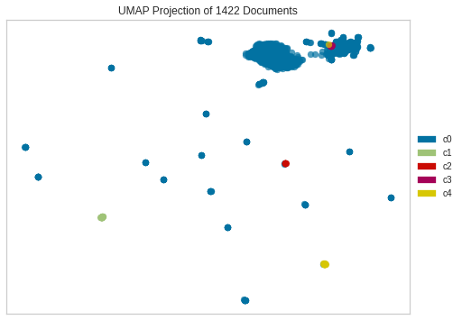

```python
plot_model(lda, plot = 'umap')
```

#### Evaluación del NLP

```python
evaluate_model(lda)
```

#### Limpieza final del dataframe a usar

```python
lda_results_df.tail()
```

|  | name | hours | is_used | bucket | Topic_0 | Topic_1 | Topic_2 | Topic_3 | Dominant_Topic | Perc_Dominant_Topic |
| --- | --- | --- | --- | --- | --- | --- | --- | --- | --- | --- |
| 1417 | file upload cloud storage setup | 40 | 0 | Backend | 0.213132 | 0.738533 | 0.024875 | 0.023460 | Topic 1 | 0.74 |
| 1418 | team crud | 16 | 0 | Backend | 0.082071 | 0.815678 | 0.052622 | 0.049629 | Topic 1 | 0.82 |
| 1419 | knowledge crud | 16 | 0 | Backend | 0.082071 | 0.815678 | 0.052622 | 0.049629 | Topic 1 | 0.82 |
| 1420 |  | 40 | 0 | Backend | 0.320131 | 0.281012 | 0.205264 | 0.193593 | Topic 0 | 0.32 |
| 1421 | deployment production | 16 | 0 | Backend | 0.825707 | 0.072042 | 0.052622 | 0.049629 | Topic 0 | 0.83 |

```python
lda_results_df = lda_results_df.drop(columns=['Dominant_Topic','Perc_Dominant_Topic','name'])
```

```python
lda_results_df.head()
```

|  | hours | is_used | bucket | Topic_0 | Topic_1 | Topic_2 | Topic_3 |
| --- | --- | --- | --- | --- | --- | --- | --- |
| 0 | 8 | 1 | Devops | 0.060157 | 0.052697 | 0.850942 | 0.036205 |
| 1 | 8 | 1 | Devops | 0.130661 | 0.114690 | 0.083770 | 0.670879 |
| 2 | 8 | 1 | Devops | 0.825707 | 0.072042 | 0.052622 | 0.049629 |
| 3 | 2 | 1 | Devops | 0.320131 | 0.281012 | 0.205264 | 0.193593 |
| 4 | 8 | 1 | Devops | 0.320131 | 0.281012 | 0.205264 | 0.193593 |

```python
# Guardado del dataset final
lda_results_df.to_csv('/content/drive/My Drive/PMO Project/final_df.csv')
```

```python
#Guardar el modelo entrenado
save_model(lda, '/content/drive/My Drive/PMO Project/Models/' + 'lda_model_pmo_v2')
```

```
Model Succesfully Saved
```